# Example statistical tests

Eric Goolsby

11/18/2021

## Common statistical test are linear models

If you want to learn a bit more about linear model-based tests (t-test, ANOVA, ANCOVA, chi-squared test, non-parameteric tests), check out [Common statistical tests are linear models: a work through](https://steverxd.github.io/Stat_tests/linearmodel.html). It provides a nice summary of what these tests do, describes how they are just special cases of linear models, and includes example R code.

## [Data Analysis and Statistics with R](https://dzchilds.github.io/stats-for-bio)

Another great resource with worked examples is [Data Analysis and Statistics with R](https://dzchilds.github.io/stats-for-bio) (by Dylan Z. Childs, Bethan J. Hindle and Philip H. Warren). You can load any of the referenced datasets by first creating the `get_data` function:

```r
get_data <- function(filename) read.csv(paste("https://raw.githubusercontent.com/dzchilds/stats-for-bio/master/data_csv/",filename,sep=""))
```

Then you can simply run something like this: `data_anme <- get_data("filename.csv")`. For example, the t-test example refers to a data frame named `morph_data`, loaded from `MORPH_DATA.CSV`:

```r
morph_data <- get_data("MORPH_DATA.CSV")
head(morph_data)
```

```
##   Colour   Weight
## 1  Green 714.3592
## 2  Green 693.4924
## 3  Green 556.2063
## 4 Purple 653.6619
## 5  Green 672.5207
## 6  Green 661.0097
```

- Is my continuous variable different from zero? [one-sample t-test](https://dzchilds.github.io/stats-for-bio/one-sample-t-tests.html)
- Are my two continuous variables statistically different from one another? [two-sample t-test](https://dzchilds.github.io/stats-for-bio/two-sample-t-test.html)
- Are two continuous variables correlated?
  - [correlation test](https://dzchilds.github.io/stats-for-bio/a-correlation-test.html)
  - [relationships and regression](https://dzchilds.github.io/stats-for-bio/relationships-and-regression.html)
  - [simple regression](https://dzchilds.github.io/stats-for-bio/simple-regression-in-r.html)
- I have continuous variables from multiple groups (i.e., like t-test but with more than two groups). Are the groups statistically different?
  - [one-way ANOVA introduction](https://dzchilds.github.io/stats-for-bio/introduction-to-one-way-anova.html)
  - [one-way ANOVA](https://dzchilds.github.io/stats-for-bio/one-way-anova-in-r.html)
- t-test, but with paired variables: [paired-sample t-test](https://dzchilds.github.io/stats-for-bio/paired-sample-t-test.html)
- I need to perform an ANOVA, but my experimental design included blocks. [ANOVA for randomied block designs](https://dzchilds.github.io/stats-for-bio/anova-for-randomised-block-designs.html)
- I want to test for an interaction effect between two variables.
  - [intro to two-way ANOVA](https://dzchilds.github.io/stats-for-bio/two-way-anova-intro.html)
  - [two-way ANOVA](https://dzchilds.github.io/stats-for-bio/two-way-anova-in-r.html)
- ANOVA, but controlling for a nuisance variable or a covariate.
  - [intro to ANCOVA](https://dzchilds.github.io/stats-for-bio/introduction-to-ancova.html)
  - [two-way ANCOVA](https://dzchilds.github.io/stats-for-bio/two-way-ancova-in-r.html)
- Model assumptions and diagnostics
  - [Assumptions and diagnostics](https://dzchilds.github.io/stats-for-bio/assumptions-diagnostics.html)
  - [Regression diagnostics](https://dzchilds.github.io/stats-for-bio/regression-diagnostics.html)
  - [Data transformations](https://dzchilds.github.io/stats-for-bio/data-transformations.html)
  - [Multiple comparison tests](https://dzchilds.github.io/stats-for-bio/multiple-comparison-tests.html)
- Counts, frequenccies, and non-parametric data
  - [Frequencies](https://dzchilds.github.io/stats-for-bio/working-with-frequencies.html)
  - [Goodness of fit tests](https://dzchilds.github.io/stats-for-bio/goodness-of-fit-tests.html)
  - [Contingency tables](https://dzchilds.github.io/stats-for-bio/contingency-tables.html)
  - [Non-parametric tests](https://dzchilds.github.io/stats-for-bio/non-parametric-tests.html)

## Exploratory relationships

We’re going to use the `GGally` package to visualize pairwise relationships, and the `easystats` packages to make data analysis easier.

```r
#install.packages("GGally")
library(GGally)
#install.packages("easystats", repos = "https://easystats.r-universe.dev")
library(easystats)
```

### Exploring correlations between multiple continuous variables

Let’s summarize correlations in the iris dataset, without accounting for species:

```r
iris_cor <- correlation(iris)

# view the results
iris_cor
```

```
## # Correlation Matrix (pearson-method)
##
## Parameter1   |   Parameter2 |     r |         95% CI | t(148) |         p
## -------------------------------------------------------------------------
## Sepal.Length |  Sepal.Width | -0.12 | [-0.27,  0.04] |  -1.44 | 0.152
## Sepal.Length | Petal.Length |  0.87 | [ 0.83,  0.91] |  21.65 | < .001***
## Sepal.Length |  Petal.Width |  0.82 | [ 0.76,  0.86] |  17.30 | < .001***
## Sepal.Width  | Petal.Length | -0.43 | [-0.55, -0.29] |  -5.77 | < .001***
## Sepal.Width  |  Petal.Width | -0.37 | [-0.50, -0.22] |  -4.79 | < .001***
## Petal.Length |  Petal.Width |  0.96 | [ 0.95,  0.97] |  43.39 | < .001***
##
## p-value adjustment method: Holm (1979)
## Observations: 150
```

```r
## or in matrix format
summary(iris_cor)
```

```
## # Correlation Matrix (pearson-method)
##
## Parameter    | Petal.Width | Petal.Length | Sepal.Width
## -------------------------------------------------------
## Sepal.Length |     0.82*** |      0.87*** |       -0.12
## Sepal.Width  |    -0.37*** |     -0.43*** |
## Petal.Length |     0.96*** |              |
##
## p-value adjustment method: Holm (1979)
```

Now let’s visualize the correlations using a few different (redundant) approaches:

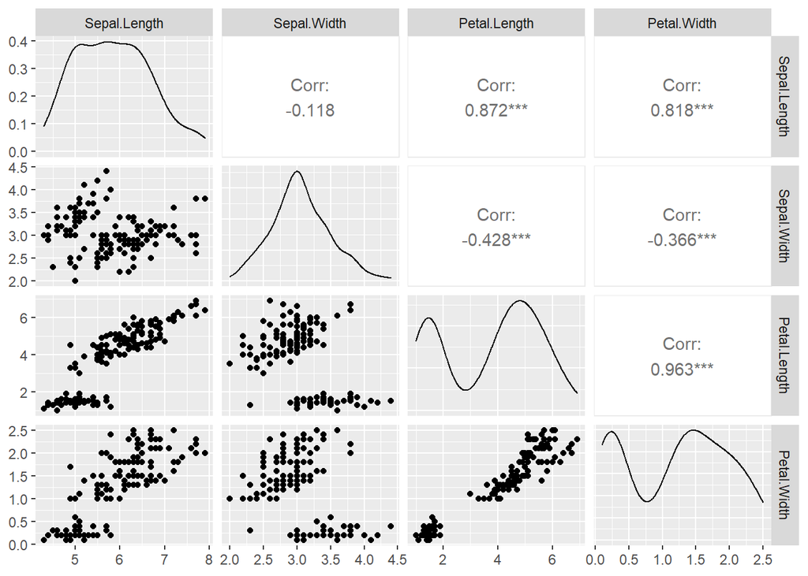

```r
ggpairs(iris,columns = 1:4)
```

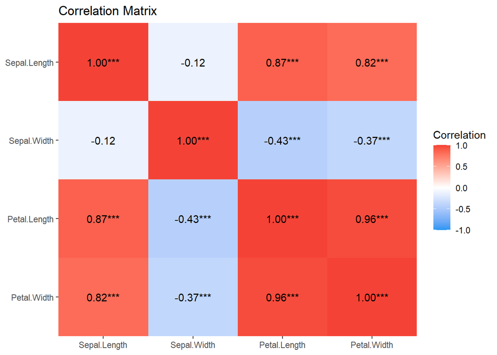

```r
iris_cor %>% summary(redundant = TRUE) %>% plot()
```

In base R, we can accomplish something similar. Optionally, first define a helper function called `panel.cor`:

```r
panel.cor <- function(x, y, digits = 2, prefix = "", size_by_cor = FALSE, ...)
{
    usr <- par("usr"); on.exit(par(usr))
    par(usr = c(0, 1, 0, 1))
    r <- abs(cor(x, y))
    txt <- format(c(r, 0.123456789), digits = digits)[1]
    txt <- paste0(prefix, txt)

    text(0.5, 0.5, txt,cex = if(size_by_cor) 0.8/strwidth(txt) else FALSE)#, cex = cex.cor * r)
}
```

Then make the pairwise plot with or without the helper function:

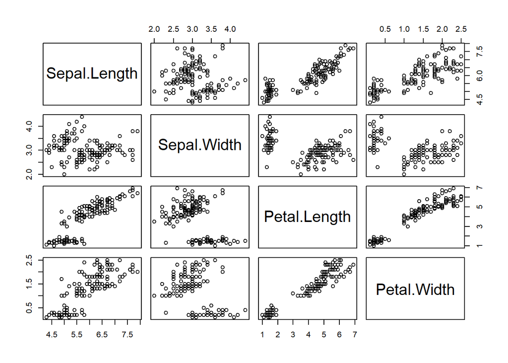

```r
# without the helper function panel.cor
pairs(iris[,1:4])
```

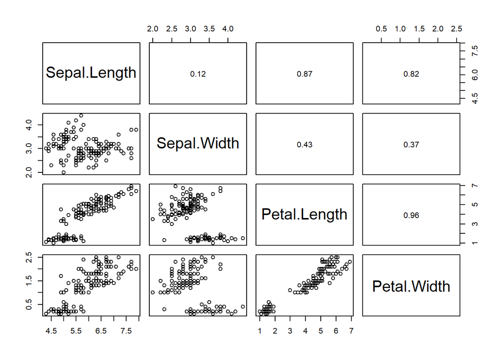

```r
# with the helper function panel.cor
pairs(iris[,1:4],upper.panel = panel.cor)
```

### Exploring correlations between multiple continuous variables with groups (e.g. Species)

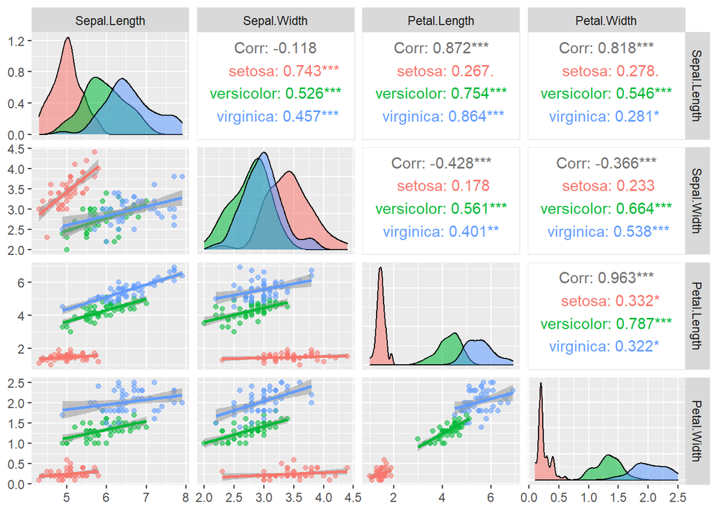

```r
ggpairs(iris, columns = 1:4, aes(color = Species, alpha = 0.5),
        lower = list(continuous = "smooth"))
```

We can’t plot by groups using this approach. Still, it’s useful:

```r
iris_cor_grouped <- iris %>%
  group_by(Species) %>%
  correlation()

iris_cor_grouped
```

```
## # Correlation Matrix (pearson-method)
##
## Group      |   Parameter1 |   Parameter2 |    r |        95% CI | t(48) |         p
## -----------------------------------------------------------------------------------
## setosa     | Sepal.Length |  Sepal.Width | 0.74 | [ 0.59, 0.85] |  7.68 | < .001***
## setosa     | Sepal.Length | Petal.Length | 0.27 | [-0.01, 0.51] |  1.92 | 0.202
## setosa     | Sepal.Length |  Petal.Width | 0.28 | [ 0.00, 0.52] |  2.01 | 0.202
## setosa     |  Sepal.Width | Petal.Length | 0.18 | [-0.11, 0.43] |  1.25 | 0.217
## setosa     |  Sepal.Width |  Petal.Width | 0.23 | [-0.05, 0.48] |  1.66 | 0.208
## setosa     | Petal.Length |  Petal.Width | 0.33 | [ 0.06, 0.56] |  2.44 | 0.093
## versicolor | Sepal.Length |  Sepal.Width | 0.53 | [ 0.29, 0.70] |  4.28 | < .001***
## versicolor | Sepal.Length | Petal.Length | 0.75 | [ 0.60, 0.85] |  7.95 | < .001***
## versicolor | Sepal.Length |  Petal.Width | 0.55 | [ 0.32, 0.72] |  4.52 | < .001***
## versicolor |  Sepal.Width | Petal.Length | 0.56 | [ 0.33, 0.73] |  4.69 | < .001***
## versicolor |  Sepal.Width |  Petal.Width | 0.66 | [ 0.47, 0.80] |  6.15 | < .001***
## versicolor | Petal.Length |  Petal.Width | 0.79 | [ 0.65, 0.87] |  8.83 | < .001***
## virginica  | Sepal.Length |  Sepal.Width | 0.46 | [ 0.20, 0.65] |  3.56 | 0.003**
## virginica  | Sepal.Length | Petal.Length | 0.86 | [ 0.77, 0.92] | 11.90 | < .001***
## virginica  | Sepal.Length |  Petal.Width | 0.28 | [ 0.00, 0.52] |  2.03 | 0.048*
## virginica  |  Sepal.Width | Petal.Length | 0.40 | [ 0.14, 0.61] |  3.03 | 0.012*
## virginica  |  Sepal.Width |  Petal.Width | 0.54 | [ 0.31, 0.71] |  4.42 | < .001***
## virginica  | Petal.Length |  Petal.Width | 0.32 | [ 0.05, 0.55] |  2.36 | 0.045*
##
## p-value adjustment method: Holm (1979)
## Observations: 50
```

```r
summary(iris_cor_grouped)
```

```
## # Correlation Matrix (pearson-method)
##
## Group      |    Parameter | Petal.Width | Petal.Length | Sepal.Width
## --------------------------------------------------------------------
## setosa     | Sepal.Length |        0.28 |         0.27 |     0.74***
## setosa     |  Sepal.Width |        0.23 |         0.18 |
## setosa     | Petal.Length |        0.33 |              |
## versicolor | Sepal.Length |     0.55*** |      0.75*** |     0.53***
## versicolor |  Sepal.Width |     0.66*** |      0.56*** |
## versicolor | Petal.Length |     0.79*** |              |
## virginica  | Sepal.Length |       0.28* |      0.86*** |      0.46**
## virginica  |  Sepal.Width |     0.54*** |        0.40* |
## virginica  | Petal.Length |       0.32* |              |
##
## p-value adjustment method: Holm (1979)
```

**Similar, but in base R:**

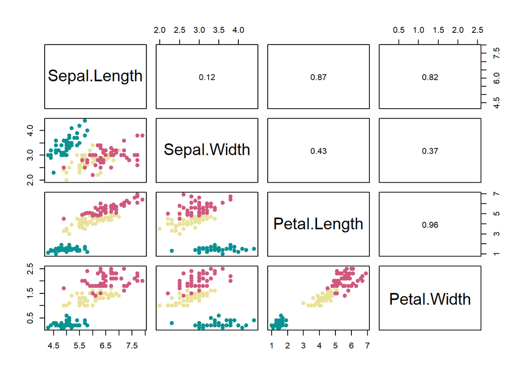

```r
pairs(iris[,1:4], col = hcl.colors(length(unique(iris$Species)), "Temps")[iris$Species],pch=19,upper.panel = panel.cor)
```

### Exploring multiple continuous and discrete variables

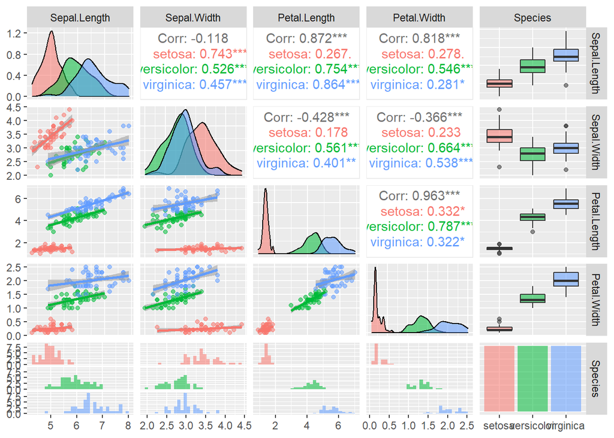

```r
ggpairs(iris, columns = 1:5, aes(color = Species, alpha = 0.5),
        lower = list(continuous = "smooth"))
```

## Linear regression

### Palmer penguins dataset

```r
#install.packages("palmerpenguins")
library(palmerpenguins)
```

Make a scatterplot of two continuous variables of interest: `body_mass_g` and `bill_length_mm`:

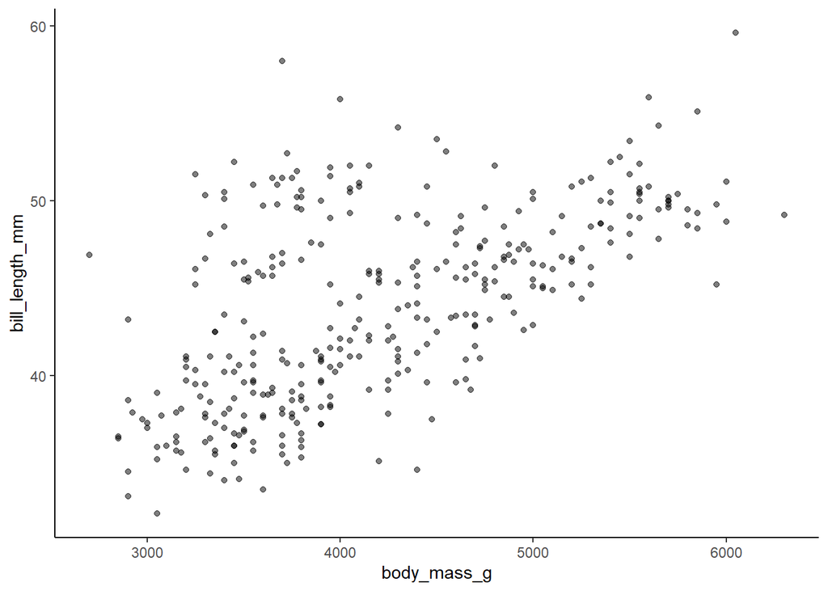

```r
plot1 <- ggplot(data = penguins) +
  geom_point(mapping = aes(x = body_mass_g,
                           y = bill_length_mm), alpha = 0.5) +
  theme_classic()
plot1
```

Now let’s fit a linear model to the data:

```r
mod1 <- lm(bill_length_mm ~ body_mass_g,data = penguins)
```

Now, let’s look at the model output and its summary output:

```r
mod1
```

```
##
## Call:
## lm(formula = bill_length_mm ~ body_mass_g, data = penguins)
##
## Coefficients:
## (Intercept)  body_mass_g
##   26.898872     0.004051
```

```r
summary(mod1)
```

```
##
## Call:
## lm(formula = bill_length_mm ~ body_mass_g, data = penguins)
##
## Residuals:
##      Min       1Q   Median       3Q      Max
## -10.1251  -3.0434  -0.8089   2.0711  16.1109
##
## Coefficients:
##              Estimate Std. Error t value Pr(>|t|)
## (Intercept) 2.690e+01  1.269e+00   21.19   <2e-16 ***
## body_mass_g 4.051e-03  2.967e-04   13.65   <2e-16 ***
## ---
## Signif. codes:  0 '***' 0.001 '**' 0.01 '*' 0.05 '.' 0.1 ' ' 1
##
## Residual standard error: 4.394 on 340 degrees of freedom
##   (2 observations deleted due to missingness)
## Multiple R-squared:  0.3542, Adjusted R-squared:  0.3523
## F-statistic: 186.4 on 1 and 340 DF,  p-value: < 2.2e-16
```

To translate this into a description, use the report function:

```r
report(mod1)
```

```
## We fitted a linear model (estimated using OLS) to predict bill_length_mm with body_mass_g (formula: bill_length_mm ~ body_mass_g). The model explains a statistically significant and substantial proportion of variance (R2 = 0.35, F(1, 340) = 186.44, p < .001, adj. R2 = 0.35). The model's intercept…
##
##   - The effect of body mass g is statistically significant and positive (beta = 4.05e-03, 95% CI [3.47e-03, 4.64e-03], t(340) = 13.65, p < .001; Std. beta = 0.60, 95% CI [0.51, 0.68])
##
## Standardized parameters were obtained by fitting the model on a standardized version of the dataset. 95% Confidence Intervals (CIs) and p-values were computed using the Wald approximation.
```

Visualize the fitted model:

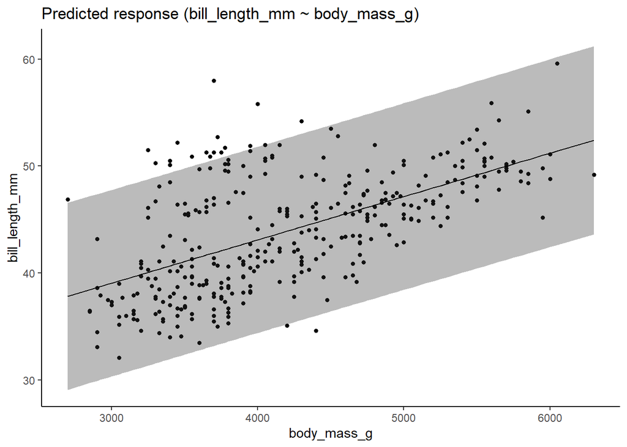

```r
mod1 %>%
  estimate_prediction() %>%
  plot() +
  theme_classic()
```

Check the assumptions of the model:

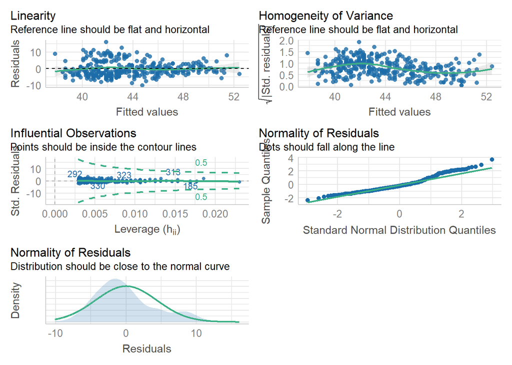

```r
check_model(mod1)
```

Let’s add species as a factor:

```r
mod2 <- lm(bill_length_mm ~ body_mass_g + species,data = penguins)
```

Now, let’s look at the model output and its summary output:

```r
mod2
```

```
##
## Call:
## lm(formula = bill_length_mm ~ body_mass_g + species, data = penguins)
##
## Coefficients:
##      (Intercept)       body_mass_g  speciesChinstrap     speciesGentoo
##        24.919471          0.003748          9.920884          3.557978
```

```r
summary(mod2)
```

```
##
## Call:
## lm(formula = bill_length_mm ~ body_mass_g + species, data = penguins)
##
## Residuals:
##     Min      1Q  Median      3Q     Max
## -6.8129 -1.6718  0.1336  1.4720  9.2902
##
## Coefficients:
##                   Estimate Std. Error t value Pr(>|t|)
## (Intercept)      2.492e+01  1.063e+00  23.443  < 2e-16 ***
## body_mass_g      3.749e-03  2.823e-04  13.276  < 2e-16 ***
## speciesChinstrap 9.921e+00  3.511e-01  28.258  < 2e-16 ***
## speciesGentoo    3.558e+00  4.858e-01   7.324 1.78e-12 ***
## ---
## Signif. codes:  0 '***' 0.001 '**' 0.01 '*' 0.05 '.' 0.1 ' ' 1
##
## Residual standard error: 2.403 on 338 degrees of freedom
##   (2 observations deleted due to missingness)
## Multiple R-squared:  0.808,  Adjusted R-squared:  0.8063
## F-statistic:   474 on 3 and 338 DF,  p-value: < 2.2e-16
```

To translate this into a description, use the report function:

```r
report(mod2)
```

```
## We fitted a linear model (estimated using OLS) to predict bill_length_mm with body_mass_g and species (formula: bill_length_mm ~ body_mass_g + species). The model explains a statistically significant and substantial proportion of variance (R2 = 0.81, F(3, 338) = 474.01, p < .001, adj. R2 = 0.81).…
##
##   - The effect of body mass g is statistically significant and positive (beta = 3.75e-03, 95% CI [3.19e-03, 4.30e-03], t(338) = 13.28, p < .001; Std. beta = 0.55, 95% CI [0.47, 0.63])
##   - The effect of species [Chinstrap] is statistically significant and positive (beta = 9.92, 95% CI [9.23, 10.61], t(338) = 28.26, p < .001; Std. beta = 1.82, 95% CI [1.69, 1.94])
##   - The effect of species [Gentoo] is statistically significant and positive (beta = 3.56, 95% CI [2.60, 4.51], t(338) = 7.32, p < .001; Std. beta = 0.65, 95% CI [0.48, 0.83])
##
## Standardized parameters were obtained by fitting the model on a standardized version of the dataset. 95% Confidence Intervals (CIs) and p-values were computed using the Wald approximation.
```

Visualize the fitted model:

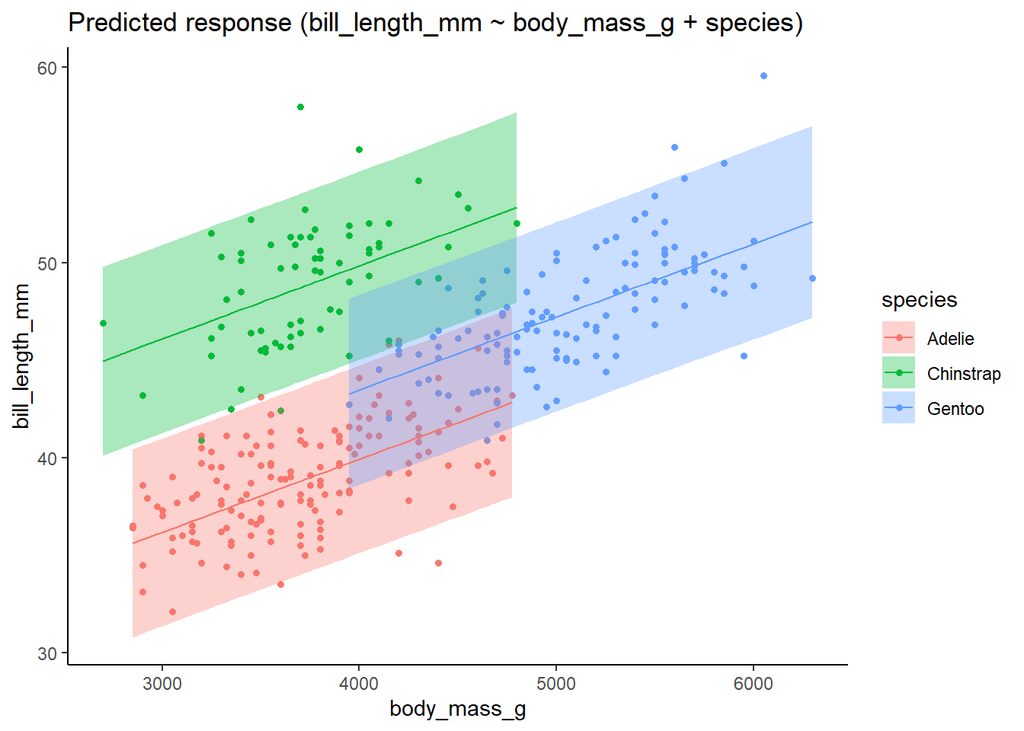

```r
mod2 %>%
  estimate_prediction() %>%
  plot() +
  theme_classic()
```

Check the assumptions of the model:

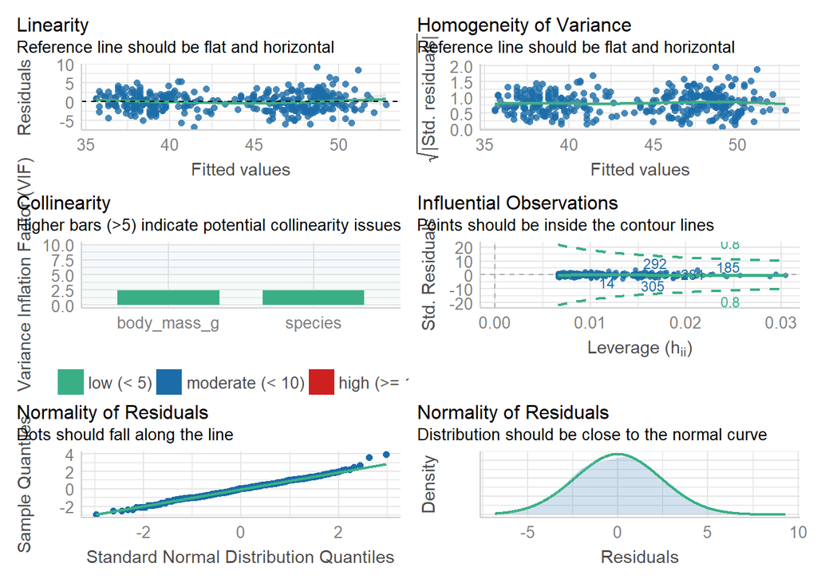

```r
check_model(mod2)
```

What if we add island as another factor:

```r
mod3 <- lm(bill_length_mm ~ body_mass_g + species + island,data = penguins)
```

Now, let’s look at the model output and its summary output:

```r
mod3
```

```
##
## Call:
## lm(formula = bill_length_mm ~ body_mass_g + species + island,
##     data = penguins)
##
## Coefficients:
##      (Intercept)       body_mass_g  speciesChinstrap     speciesGentoo
##        25.083029          0.003745         10.164662          3.413129
##      islandDream   islandTorgersen
##        -0.393576         -0.011712
```

```r
summary(mod3)
```

```
##
## Call:
## lm(formula = bill_length_mm ~ body_mass_g + species + island,
##     data = penguins)
##
## Residuals:
##    Min     1Q Median     3Q    Max
## -6.949 -1.673  0.100  1.497  9.290
##
## Coefficients:
##                    Estimate Std. Error t value Pr(>|t|)
## (Intercept)      25.0830286  1.1101663  22.594  < 2e-16 ***
## body_mass_g       0.0037448  0.0002828  13.241  < 2e-16 ***
## speciesChinstrap 10.1646621  0.4345343  23.392  < 2e-16 ***
## speciesGentoo     3.4131290  0.5728131   5.959 6.43e-09 ***
## islandDream      -0.3935763  0.4849432  -0.812    0.418
## islandTorgersen  -0.0117121  0.4952551  -0.024    0.981
## ---
## Signif. codes:  0 '***' 0.001 '**' 0.01 '*' 0.05 '.' 0.1 ' ' 1
##
## Residual standard error: 2.407 on 336 degrees of freedom
##   (2 observations deleted due to missingness)
## Multiple R-squared:  0.8085, Adjusted R-squared:  0.8056
## F-statistic: 283.7 on 5 and 336 DF,  p-value: < 2.2e-16
```

Probably not a good idea to include island in this model!

```r
report(mod3)
```

```
## We fitted a linear model (estimated using OLS) to predict bill_length_mm with body_mass_g, species and island (formula: bill_length_mm ~ body_mass_g + species + island). The model explains a statistically significant and substantial proportion of variance (R2 = 0.81, F(5, 336) = 283.67, p < .001,…
##
##   - The effect of body mass g is statistically significant and positive (beta = 3.74e-03, 95% CI [3.19e-03, 4.30e-03], t(336) = 13.24, p < .001; Std. beta = 0.55, 95% CI [0.47, 0.63])
##   - The effect of species [Chinstrap] is statistically significant and positive (beta = 10.16, 95% CI [9.31, 11.02], t(336) = 23.39, p < .001; Std. beta = 1.86, 95% CI [1.71, 2.02])
##   - The effect of species [Gentoo] is statistically significant and positive (beta = 3.41, 95% CI [2.29, 4.54], t(336) = 5.96, p < .001; Std. beta = 0.63, 95% CI [0.42, 0.83])
##   - The effect of island [Dream] is statistically non-significant and negative (beta = -0.39, 95% CI [-1.35, 0.56], t(336) = -0.81, p = 0.418; Std. beta = -0.07, 95% CI [-0.25, 0.10])
##   - The effect of island [Torgersen] is statistically non-significant and negative (beta = -0.01, 95% CI [-0.99, 0.96], t(336) = -0.02, p = 0.981; Std. beta = -2.15e-03, 95% CI [-0.18, 0.18])
##
## Standardized parameters were obtained by fitting the model on a standardized version of the dataset. 95% Confidence Intervals (CIs) and p-values were computed using the Wald approximation.
```

Let’s compare all 3 models:

```r
compare_performance(mod1,mod2,mod3,rank = TRUE)
```

```
## # Comparison of Model Performance Indices
##
## Name | Model |    R2 | R2 (adj.) |  RMSE | Sigma | AIC weights | BIC weights | Performance-Score
## ------------------------------------------------------------------------------------------------
## mod2 |    lm | 0.808 |     0.806 | 2.389 | 2.403 |       0.823 |       0.995 |            99.95%
## mod3 |    lm | 0.808 |     0.806 | 2.386 | 2.407 |       0.177 |       0.005 |            70.28%
## mod1 |    lm | 0.354 |     0.352 | 4.381 | 4.394 |     < 0.001 |     < 0.001 |             0.00%
```

**PLEASE NOTE: This is just an example analysis to demonstrate how these functions work. Haphazardly adding variables to models and then performing automated model selection is a very bad idea. Building models requires an understanding of statistical assumptions and biological (etc) mechanisms.**

Assuming that you have read the above warning and understand that automatic model selection is not a substitute for statistical understanding – just for demonstration purposes, let’s run mixed effects models using the `lme4` package. First, a random intercept model with `species` as a random effect:

```r
#install.packages("lme4")
library(lme4)
# random intercept model
mod4 <- lmer(bill_length_mm ~ body_mass_g + (1|species),data = penguins)
mod4
```

```
## Linear mixed model fit by REML ['lmerMod']
## Formula: bill_length_mm ~ body_mass_g + (1 | species)
##    Data: penguins
## REML criterion at convergence: 1597.285
## Random effects:
##  Groups   Name        Std.Dev.
##  species  (Intercept) 5.023
##  Residual             2.403
## Number of obs: 342, groups:  species, 3
## Fixed Effects:
## (Intercept)  body_mass_g
##   29.423677     0.003745
```

```r
summary(mod4)
```

```
## Linear mixed model fit by REML ['lmerMod']
## Formula: bill_length_mm ~ body_mass_g + (1 | species)
##    Data: penguins
##
## REML criterion at convergence: 1597.3
##
## Scaled residuals:
##     Min      1Q  Median      3Q     Max
## -2.8368 -0.6949  0.0543  0.6105  3.8734
##
## Random effects:
##  Groups   Name        Variance Std.Dev.
##  species  (Intercept) 25.232   5.023
##  Residual              5.775   2.403
## Number of obs: 342, groups:  species, 3
##
## Fixed effects:
##              Estimate Std. Error t value
## (Intercept) 2.942e+01  3.132e+00   9.394
## body_mass_g 3.745e-03  2.818e-04  13.290
##
## Correlation of Fixed Effects:
##             (Intr)
## body_mass_g -0.375
```

```r
report(mod4)
```

[output not shown]

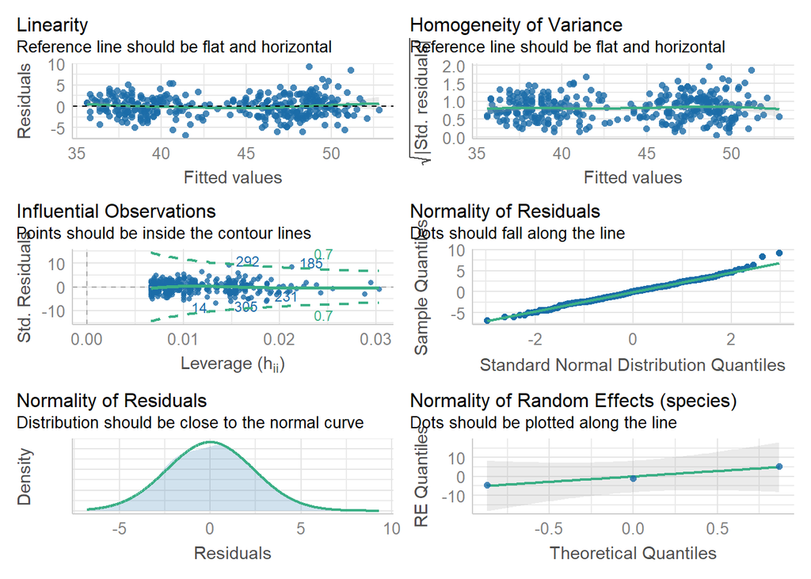

```r
check_model(mod4)
```

Next, a random intercept and random slopes model, with `species` as a random effect and `body_mass_g` with random slopes:

```r
# random intercept + random slopes model
mod5 <- lmer(bill_length_mm ~ body_mass_g + (body_mass_g|species),data = penguins)
```

```
## boundary (singular) fit: see ?isSingular
```

```r
mod5
```

```
## Linear mixed model fit by REML ['lmerMod']
## Formula: bill_length_mm ~ body_mass_g + (body_mass_g | species)
##    Data: penguins
## REML criterion at convergence: 1596.098
## Random effects:
##  Groups   Name        Std.Dev. Corr
##  species  (Intercept) 0.698575
##           body_mass_g 0.001034 1.00
##  Residual             2.399059
## Number of obs: 342, groups:  species, 3
## Fixed Effects:
## (Intercept)  body_mass_g
##    28.07282      0.00409
## optimizer (nloptwrap) convergence code: 0 (OK) ; 0 optimizer warnings; 1 lme4 warnings
```

```r
summary(mod5)
```

```
## Linear mixed model fit by REML ['lmerMod']
## Formula: bill_length_mm ~ body_mass_g + (body_mass_g | species)
##    Data: penguins
##
## REML criterion at convergence: 1596.1
##
## Scaled residuals:
##     Min      1Q  Median      3Q     Max
## -2.6515 -0.6698  0.0401  0.6153  3.9153
##
## Random effects:
##  Groups   Name        Variance  Std.Dev. Corr
##  species  (Intercept) 4.880e-01 0.698575
##           body_mass_g 1.068e-06 0.001034 1.00
##  Residual             5.755e+00 2.399059
## Number of obs: 342, groups:  species, 3
##
## Fixed effects:
##              Estimate Std. Error t value
## (Intercept) 2.807e+01  1.243e+00  22.578
## body_mass_g 4.090e-03  6.617e-04   6.181
##
## Correlation of Fixed Effects:
##             (Intr)
## body_mass_g -0.113
## optimizer (nloptwrap) convergence code: 0 (OK)
## boundary (singular) fit: see ?isSingular
```

```r
report(mod5)
```

```
## boundary (singular) fit: see ?isSingular
```

```
## Random effect variances not available. Returned R2 does not account for random effects.
```

```
## boundary (singular) fit: see ?isSingular
```

```
## Random effect variances not available. Returned R2 does not account for random effects.
```

[output not shown]

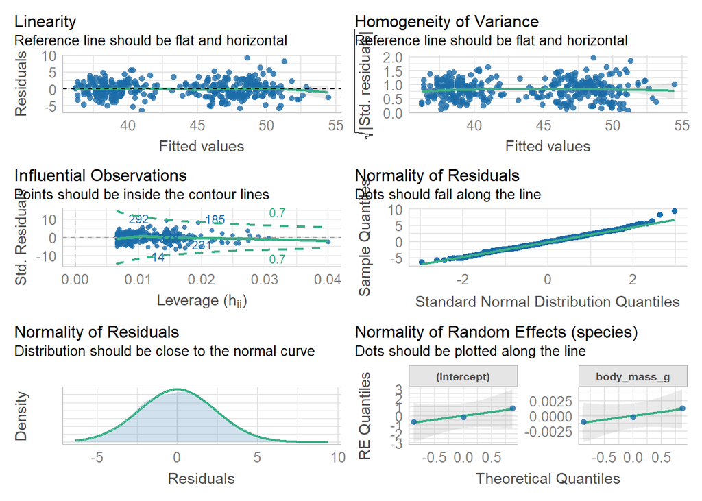

```r
check_model(mod5)
```

And finally, compare the performance of all 5 models:

```r
compare_performance(mod1,mod2,mod3,mod4,mod5,rank = TRUE)
```

```
## Random effect variances not available. Returned R2 does not account for random effects.
```

```
## # Comparison of Model Performance Indices
##
## Name |   Model |  RMSE | Sigma | AIC weights | BIC weights | Performance-Score
## ------------------------------------------------------------------------------
## mod2 |      lm | 2.389 | 2.403 |       0.823 |       0.995 |            99.88%
## mod3 |      lm | 2.386 | 2.407 |       0.177 |       0.005 |            55.37%
## mod5 | lmerMod | 2.383 | 2.399 |     < 0.001 |     < 0.001 |            50.00%
## mod4 | lmerMod | 2.389 | 2.403 |     < 0.001 |     < 0.001 |            49.88%
## mod1 |      lm | 4.381 | 4.394 |     < 0.001 |     < 0.001 |             0.00%
```

## Misc examples

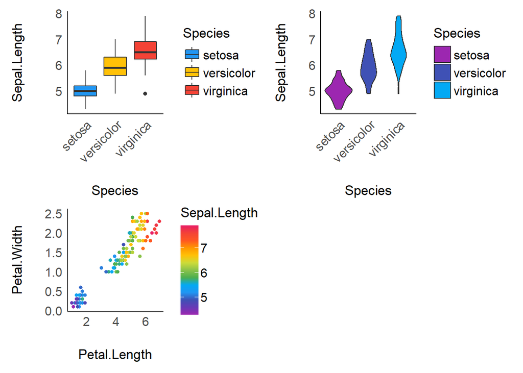

```r
p1 <- ggplot(iris, aes(x = Species, y = Sepal.Length, fill = Species)) +
  geom_boxplot() +
  theme_modern(axis.text.angle = 45) +
  scale_fill_material_d()

p2 <- ggplot(iris, aes(x = Species, y = Sepal.Length, fill = Species)) +
  geom_violin() +
  theme_modern(axis.text.angle = 45) +
  scale_fill_material_d(palette = "ice")

p3 <- ggplot(iris, aes(x = Petal.Length, y = Petal.Width, color = Sepal.Length)) +
  geom_point2() +
  theme_modern() +
  scale_color_material_c(palette = "rainbow")

plots(p1, p2, p3, n_columns = 2)
```

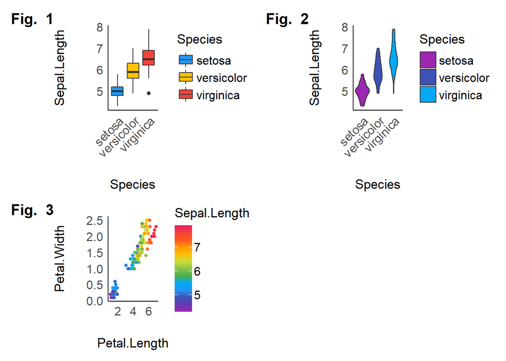

```r
plots(p1, p2, p3,
  n_columns = 2,
  tags = paste("Fig. ", 1:3)
)
```

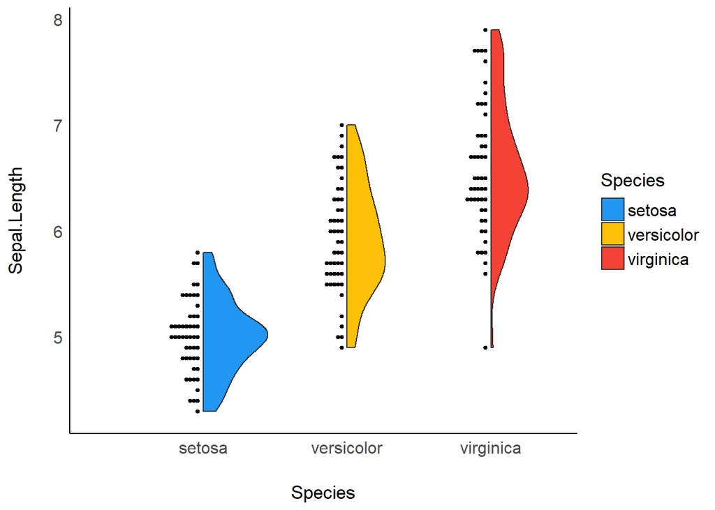

```r
ggplot(iris, aes(x = Species, y = Sepal.Length, fill = Species)) +
  geom_violindot(fill_dots = "black") +
  theme_modern() +
  scale_fill_material_d()
```

## Beware of Anscombe’s quartet!

```r
ff <- y ~ x
mods <- setNames(as.list(1:4), paste0("lm", 1:4))
for(i in 1:4) {
  ff[2:3] <- lapply(paste0(c("y","x"), i), as.name)
  ## or   ff[[2]] <- as.name(paste0("y", i))
  ##      ff[[3]] <- as.name(paste0("x", i))
  mods[[i]] <- lmi <- lm(ff, data = anscombe)
  print(anova(lmi))
}
```

```
## Analysis of Variance Table
##
## Response: y1
##           Df Sum Sq Mean Sq F value  Pr(>F)
## x1         1 27.510 27.5100   17.99 0.00217 **
## Residuals  9 13.763  1.5292
## ---
## Signif. codes:  0 '***' 0.001 '**' 0.01 '*' 0.05 '.' 0.1 ' ' 1
## Analysis of Variance Table
##
## Response: y2
##           Df Sum Sq Mean Sq F value   Pr(>F)
## x2         1 27.500 27.5000  17.966 0.002179 **
## Residuals  9 13.776  1.5307
## ---
## Signif. codes:  0 '***' 0.001 '**' 0.01 '*' 0.05 '.' 0.1 ' ' 1
## Analysis of Variance Table
##
## Response: y3
##           Df Sum Sq Mean Sq F value   Pr(>F)
## x3         1 27.470 27.4700  17.972 0.002176 **
## Residuals  9 13.756  1.5285
## ---
## Signif. codes:  0 '***' 0.001 '**' 0.01 '*' 0.05 '.' 0.1 ' ' 1
## Analysis of Variance Table
##
## Response: y4
##           Df Sum Sq Mean Sq F value   Pr(>F)
## x4         1 27.490 27.4900  18.003 0.002165 **
## Residuals  9 13.742  1.5269
## ---
## Signif. codes:  0 '***' 0.001 '**' 0.01 '*' 0.05 '.' 0.1 ' ' 1
```

```r
## See how close they are (numerically!)
sapply(mods, coef)
```

```
##                   lm1      lm2       lm3       lm4
## (Intercept) 3.0000909 3.000909 3.0024545 3.0017273
## x1          0.5000909 0.500000 0.4997273 0.4999091
```

```r
lapply(mods, function(fm) coef(summary(fm)))
```

```
## $lm1
##              Estimate Std. Error  t value    Pr(>|t|)
## (Intercept) 3.0000909  1.1247468 2.667348 0.025734051
## x1          0.5000909  0.1179055 4.241455 0.002169629
##
## $lm2
##             Estimate Std. Error  t value    Pr(>|t|)
## (Intercept) 3.000909  1.1253024 2.666758 0.025758941
## x2          0.500000  0.1179637 4.238590 0.002178816
##
## $lm3
##              Estimate Std. Error  t value    Pr(>|t|)
## (Intercept) 3.0024545  1.1244812 2.670080 0.025619109
## x3          0.4997273  0.1178777 4.239372 0.002176305
##
## $lm4
##              Estimate Std. Error  t value    Pr(>|t|)
## (Intercept) 3.0017273  1.1239211 2.670763 0.025590425
## x4          0.4999091  0.1178189 4.243028 0.002164602
```

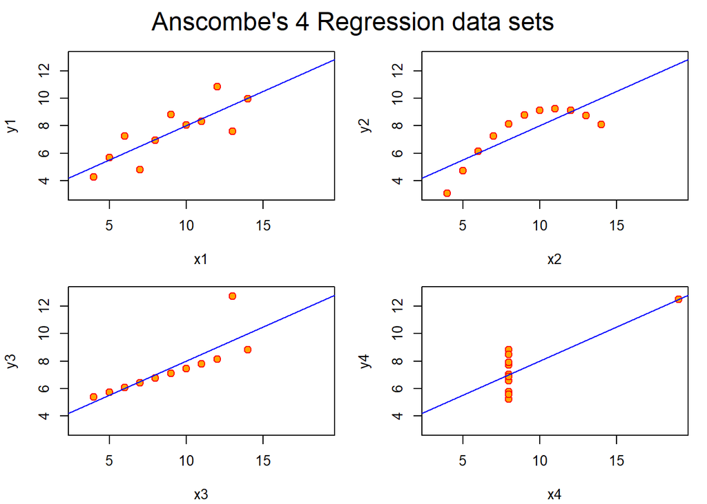

```r
## Now, do what you should have done in the first place: PLOTS
op <- par(mfrow = c(2, 2), mar = 0.1+c(4,4,1,1), oma =  c(0, 0, 2, 0))
for(i in 1:4) {
  ff[2:3] <- lapply(paste0(c("y","x"), i), as.name)
  plot(ff, data = anscombe, col = "red", pch = 21, bg = "orange", cex = 1.2,
       xlim = c(3, 19), ylim = c(3, 13))
  abline(mods[[i]], col = "blue")
}
mtext("Anscombe's 4 Regression data sets", outer = TRUE, cex = 1.5)
```

```r
par(op)
```